# Part 1: Simulation Exercise

Ivan Gimenez

January 7, 2017

## Assignment Scope

In this assignment, we set

```r
set.seed(42)
lambda=0.2
m=40
n=10000
```

where we use lambda = 0.2 for all of the simulations, assume m = 40 averages of exponentials, and each simulation is repeated n = 10000 times

## 40-averaged Exponential Distribution

Lets first plot an approximation of the distribution of 10^{4} averages of 40 random exponentials. The Central Limit Theorem (CLT) states that given a distribution with a mean $\mu$ and variance $\sigma^2$, the sampling distribution of the mean approaches a normal distribution with a mean ($\mu$) and a variance $\sigma^2/n$ as $n$ increases.

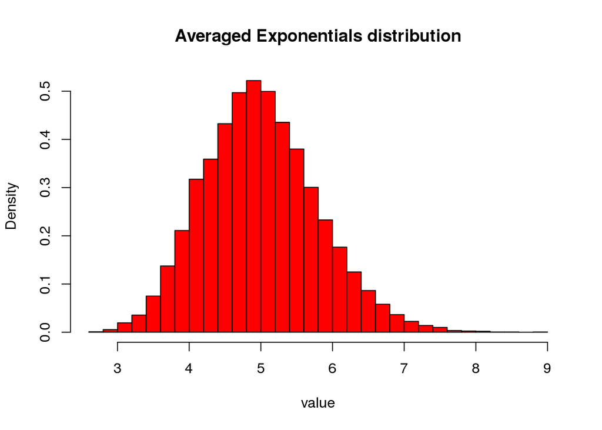

```r
avg_exps <- replicate(n, mean(rexp(m, lambda)))
hist(avg_exps, breaks=m, col='red', xlab='value',
     main="Averaged Exponentials distribution", freq=FALSE)
```

## Sample Mean versus Theoretical Mean

This section compares the mean of the sampling distribution of the sample mean versus the theoretical mean of the exponential distribution, known to be (1/lambda). We will show that, as stated in the CLT, the averaging of exponentials will give us a good estimator of the mean.

```r
simulated.mean <- mean(avg_exps)
expected.mean <- 1/lambda
```

| Sampled | Expected |
| --- | --- |
| 4.9971068 | 5 |

which seems to agree with the CLT, that states that given a distribution with a mean $\mu$ and variance $\sigma^2$, the sampling distribution of the mean approaches a normal distribution with a mean ($\mu$).

## Sample Variance versus Theoretical Variance

This section compares the variance of the sampling distribution of the sample mean versus the theoretical variance of the exponential distribution, known to be (1/lambda)^2/m

```r
simulated.var <- var(avg_exps)
expected.var <- (1/lambda)^2/m
```

| Sampled | Expected |
| --- | --- |
| 0.6279625 | 0.625 |

which seems to agree with the CLT, that states that given a distribution with a mean $\mu$ and variance $\sigma^2$, the sampling distribution of the mean approaches a normal distribution with variance $\sigma^2/n$ as n increases.

## Distribution

This section will show that the averaged exponentials distribution is approximately normal.

First we will show graphically that the sample distribution closely resembles a Normal distribution, centered at 5 with an standard deviation of 0.7905694

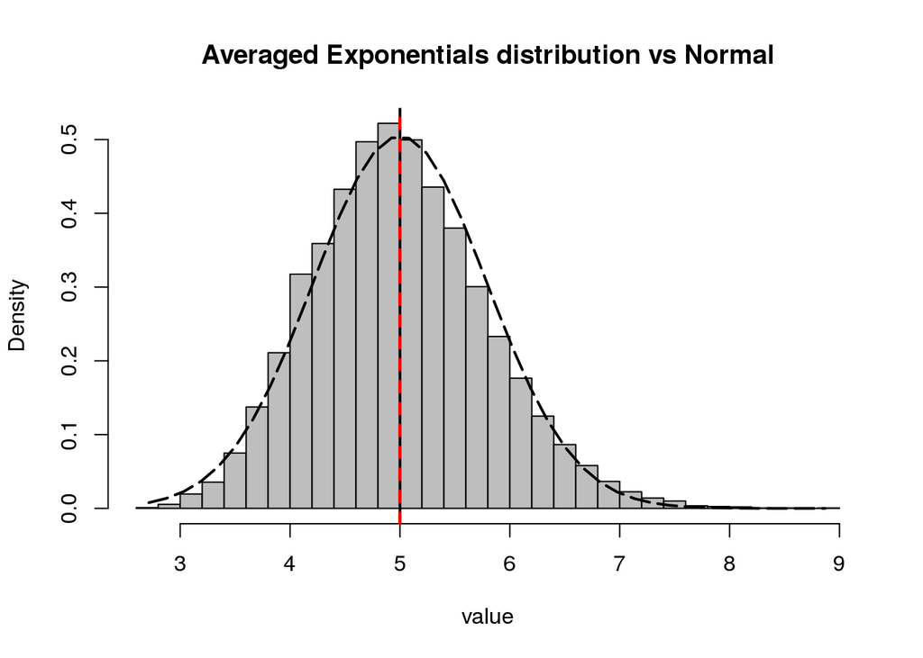

```r
rx <- range(avg_exps)
x <- seq(rx[1], rx[2], length=m)
y <- dnorm(x, mean=expected.mean, sd=sqrt(expected.var))
hist(avg_exps,breaks=m,freq=FALSE,col="grey",xlab="value",
     main="Averaged Exponentials distribution vs Normal")
lines(x, y, pch=22, col="black", lty=5, lwd=2)
# plots the expected mean in a solid black line
abline(v = expected.mean, col = "black", lwd=2)
# plots the populaton mean in a dashed red line
abline(v = simulated.mean, col = "red", lty=2,lwd=2)
```

Moreover, we can plot a quantile-to-quantile comparision plot, also known as Q-Q plot, in order to compare the quantiles between the averaged exponential sample distribution and the normal distribuition

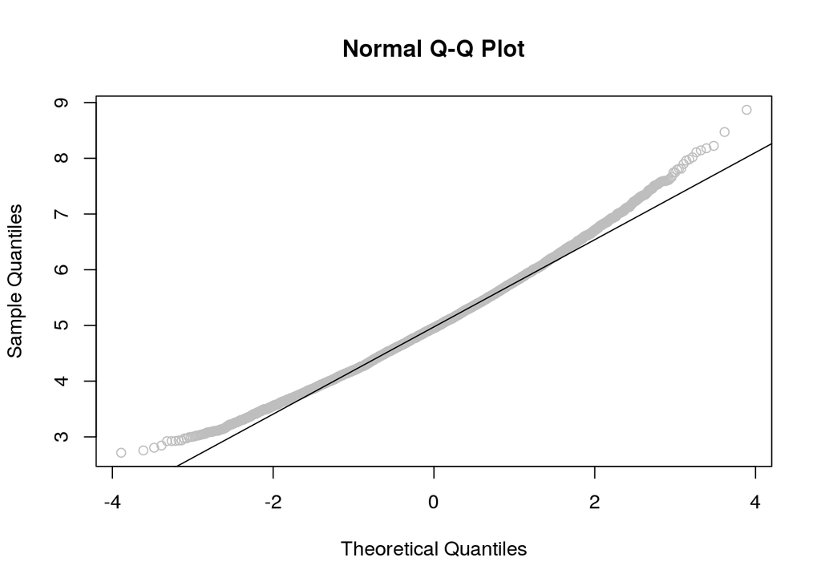

```r
qqnorm(avg_exps, main="Normal Q-Q Plot", xlab="Theoretical Quantiles",
       ylab="Sample Quantiles", col="grey")
qqline(avg_exps, col="black")
```